# Ruggedness and GDP Analysis

Pascal Bärtschi

2023-08-20

### Introduction

In this analysis, we will investigate the relationship between ruggedness, GDP, and the continent of Africa. We’ll explore data transformations, visualizations, and use ANCOVA to determine whether there is a significantly different relationship between GDP and ruggedness in countries within and outside of Africa. Let’s get started! Clear Brain and Setup

We’ll start by loading necessary libraries and importing the data set.

```r
# Importing libraries
suppressPackageStartupMessages({
  # Importing libraries
  library("ggplot2")
  library("dplyr")
  library("ggfortify")
  library('tidyverse')
  library('GGally')
})


# Load data

data <- read.csv('data/rugged.csv', stringsAsFactors = T)
```

### Data Exploration

Let’s begin by visualizing the distribution of the rgd_ppc_2000 variable using a histogram.

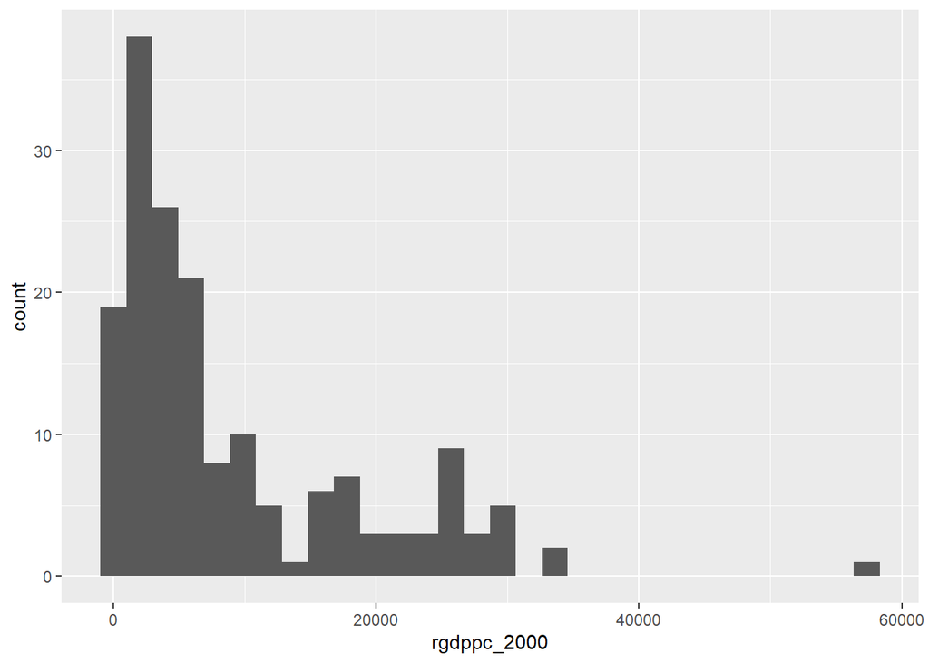

```r
ggplot(data, aes(x= rgdppc_2000)) +
  geom_histogram()
```

To deal with the skewed distribution, we’ll apply a logarithmic transformation to the variable.

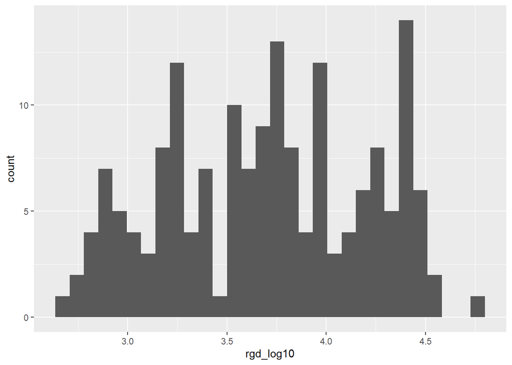

```r
data <- mutate(data, rgd_log10 = log10(rgdppc_2000))

ggplot(data, aes(x= rgd_log10)) +
  geom_histogram()
```

### Creating New Variables

We’ll create a new categorical variable cont_africa1 based on the conf_africa variable to distinguish between African and non-African countries.

```r
data <- mutate(data, cont_africa1 = as.factor(ifelse(data$cont_africa == 1, 'Africa', 'non Africa')))
# Check distribution of countries
table(data$cont_africa1)
```

```
##
##     Africa non Africa
##         57        177
```

### Ruggedness and Continent Relationship

Let’s explore the distribution of ruggedness and its potential relationship with the continent.

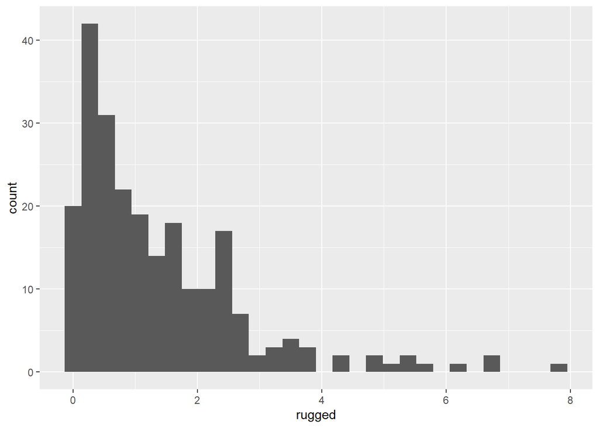

```r
ggplot(data, aes(x= rugged)) +
  geom_histogram()
```

```r
data %>%
  arrange(desc(rugged)) %>%
  select(country) %>%
  head(5)
```

```
##     country
## 1 Gibraltar
## 2    Bhutan
## 3    Monaco
## 4   Lesotho
## 5   Andorra
```

### Handling Missing Values

We’ll remove missing values and create a new dataset for further analysis.

```r
sum(is.na(data$rgd_log10))
```

```
## [1] 64
```

```r
datar <- na.omit(select(data, rugged, cont_africa1, rgd_log10))

# Check distribution of continent in the new dataset
table(datar$cont_africa1)
```

```
##
##     Africa non Africa
##         49        121
```

### Visualizing Relationships

Let’s visualize the relationship between ruggedness, log-transformed GDP, and the continent using a scatter plot.

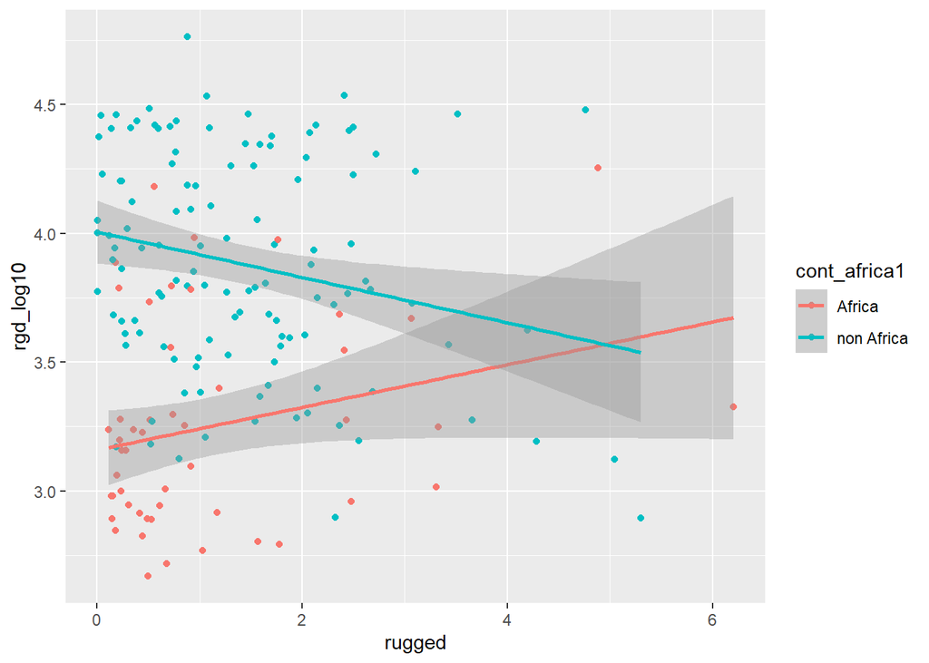

```r
ggplot(datar, aes(x = rugged, y = rgd_log10, color = cont_africa1)) +
  geom_point() +
  geom_smooth(method = 'lm')
```

### ANCOVA Analysis

We’ll conduct an ANCOVA analysis to examine the significance of the relationship between GDP and ruggedness, accounting for the effect of the continent.

```r
m1 <- lm(rgd_log10 ~ rugged * cont_africa1, data = datar)
summary(m1)
```

```
##
## Call:
## lm(formula = rgd_log10 ~ rugged * cont_africa1, data = datar)
##
## Residuals:
##      Min       1Q   Median       3Q      Max
## -0.90455 -0.32163 -0.02505  0.36088  0.97572
##
## Coefficients:
##                               Estimate Std. Error t value Pr(>|t|)
## (Intercept)                    3.15957    0.07786  40.579  < 2e-16 ***
## rugged                         0.08275    0.04624   1.789  0.07537 .
## cont_africa1non Africa         0.84603    0.09870   8.572 6.79e-15 ***
## rugged:cont_africa1non Africa -0.17085    0.05717  -2.989  0.00323 **
## ---
## Signif. codes:  0 '***' 0.001 '**' 0.01 '*' 0.05 '.' 0.1 ' ' 1
##
## Residual standard error: 0.4099 on 166 degrees of freedom
## Multiple R-squared:  0.3569, Adjusted R-squared:  0.3453
## F-statistic: 30.71 on 3 and 166 DF,  p-value: 7.595e-16
```

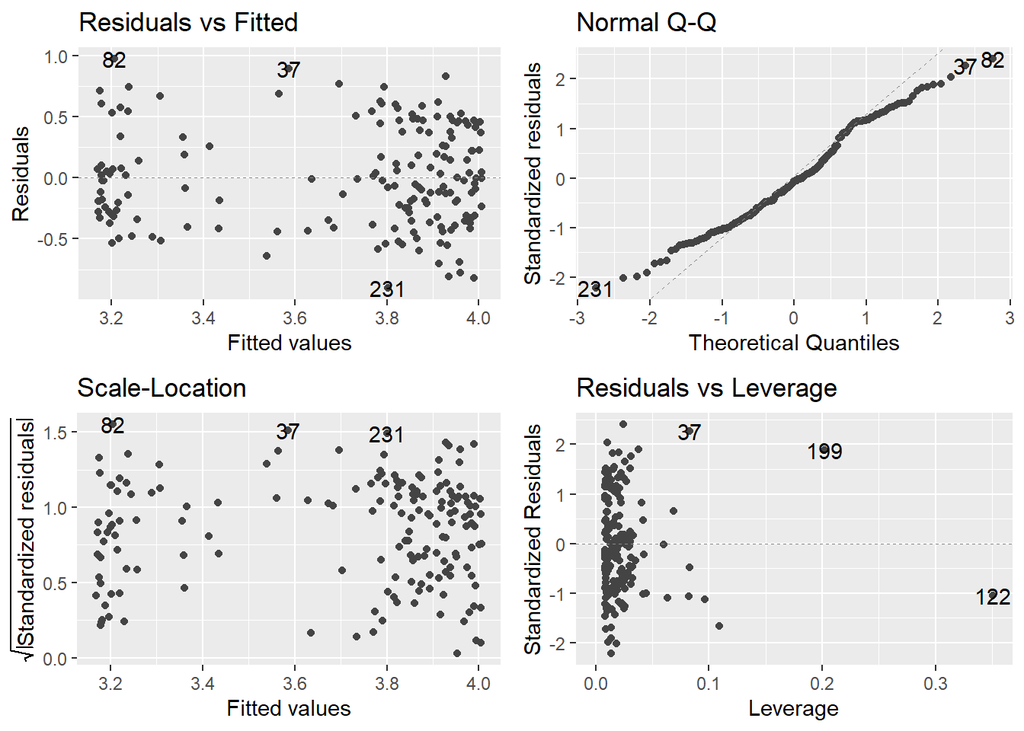

```r
autoplot(m1, smooth.colour = NA)
```

### Distribution of Residuals

Let’s visualize the distribution of residuals to assess the assumptions of the ANCOVA model.

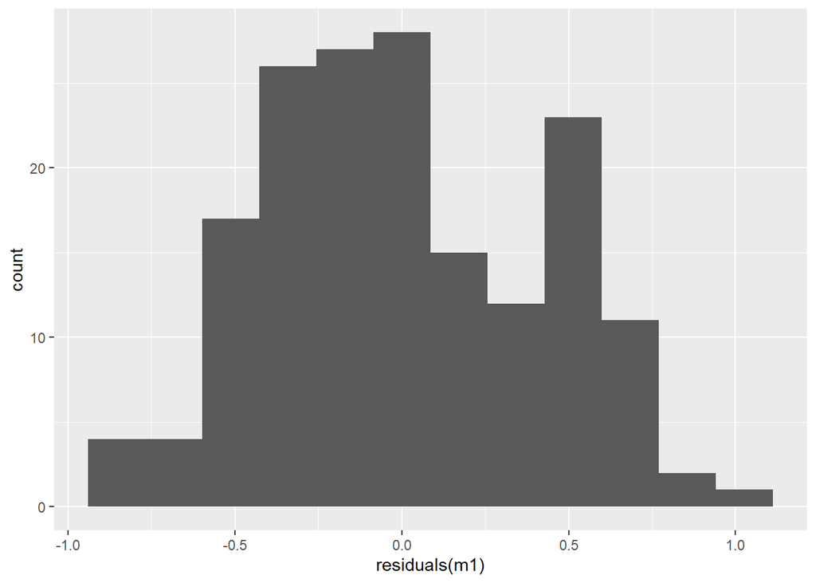

```r
resid <- residuals(m1)

ggplot(m1, aes(x = residuals(m1))) +
  geom_histogram(bins = 12)
```

### Predictions and Visualization

We’ll generate predictions using the ANCOVA model and visualize the results.

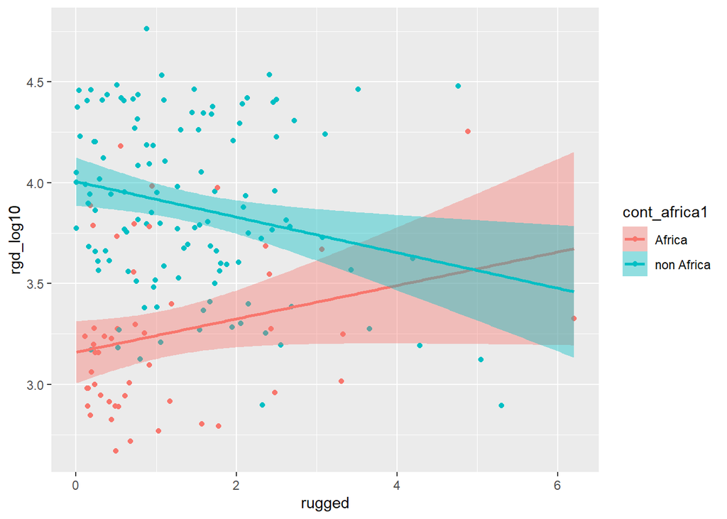

```r
new.x <- expand.grid(rugged = seq(min(datar$rugged), max(datar$rugged), length.out = 170),
                     cont_africa1 = levels(datar$cont_africa1))

pred_gdp <- predict(m1, newdata = new.x, interval = 'confidence')

addThese_gdp <- data.frame(new.x, pred_gdp)
addThese_gdp <- rename(addThese_gdp, rgd_log10 = fit)

ggplot(datar, aes(x = rugged, y = rgd_log10, colour = cont_africa1)) +
  geom_point() +
  geom_smooth(data = addThese_gdp, aes(ymin = lwr, ymax = upr, fill = cont_africa1),
              stat = 'identity')
```

### ANOVA Analysis

Finally, let’s perform ANOVA to draw conclusions about the significance of the relationships we’ve explored.

```r
anova(m1)
```

```
## Analysis of Variance Table
##
## Response: rgd_log10
##                      Df  Sum Sq Mean Sq F value    Pr(>F)
## rugged                1  0.0003  0.0003  0.0021  0.963744
## cont_africa1          1 13.9799 13.9799 83.2013 2.397e-16 ***
## rugged:cont_africa1   1  1.5007  1.5007  8.9313  0.003229 **
## Residuals           166 27.8922  0.1680
## ---
## Signif. codes:  0 '***' 0.001 '**' 0.01 '*' 0.05 '.' 0.1 ' ' 1
```

### Conclusions

In conclusion, our ANCOVA analysis reveals that there is a significantly different relationship between GDP and ruggedness in countries within and outside of Africa (p-value = 0.0032). This implies that the continent has a significant influence on this relationship. These findings provide valuable insights into the interactions between economic and geographical factors.